# Topic 5-02: Cluster and summarize

Zuguang Gu z.gu@dkfz.de

2025-05-25

There are two types of similarity methods, the count-based and semantic-based. We look at them separately.

## Count-based similarities

As an example, we use significant gene sets from ORA on the p53 dataset.

```r
lt = readRDS(system.file("extdata", "p53_expr.rds", package = "GSEAtutorial"))
expr = lt$expr
condition = lt$condition

ln = strsplit(readLines(system.file("extdata", "c2.symbols.gmt", package = "GSEAtutorial")), "\t")
gs = lapply(ln, function(x) x[-(1:2)])
names(gs) = sapply(ln, function(x) x[1])

library(genefilter)
tdf = rowttests(expr, factor(condition))
tdf$fdr = p.adjust(tdf$p.value, "BH")

diff = rownames(expr)[abs(tdf$statistic) > 2]
tb_ora = ora(diff, universe = rownames(expr), gene_sets = gs)
sig = tb_ora$gene_set[tb_ora$p_value < 0.05]
```

We suggest to only use the significant genes when calculating the similarities.

```r
gs2 = lapply(gs[sig], function(x) intersect(x, diff))
```

Additionally adding the gene weight can sometimes improve the similarity patterns.

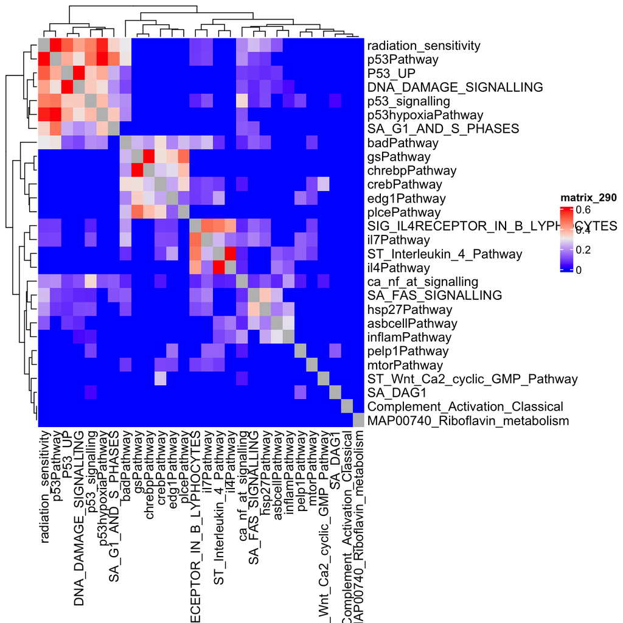

```r
w = tdf$statistic
names(w) = rownames(tdf)

sm = jaccard(gs2, weight = abs(w))
diag(sm) = NA
library(ComplexHeatmap)
Heatmap(sm)
```

The block-pattern is very obvious. You can split it by hierarchical clustering + cutree, kmeans or any clustering methods. We recommend to use the graph-based clustering methods.

The similarity matrix can be thought of as an adjacency matrix. The **igraph** package provides many graph-based clustering methods.

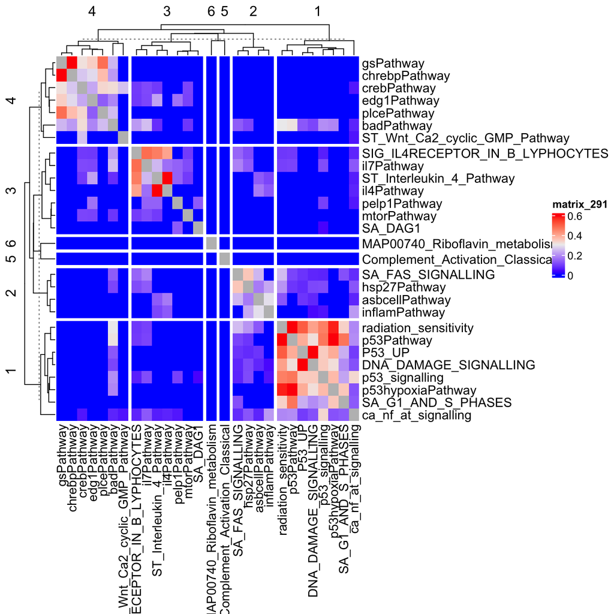

```r
library(igraph)
g = graph_from_adjacency_matrix(sm, weighted = TRUE, mode = "upper", diag = FALSE)
cl = membership(cluster_louvain(g))
Heatmap(sm, row_split = cl, column_split = cl)
```

Clustering the gene sets is fairly easy. However, this is not the end of the analysis. We need to summarize the commonness of genesets in a cluster. Note the similarity is count-based, then these genesets must share some common genes, i.e., the driving genes that cluster the genesets.

Taking the geneset cluster 1 as an example, which is related to “P53”-related functions.

```r
gs2[cl == 1]
```

```
## $P53_UP
## [1] "BAX"     "BBC3"    "BTG2"    "CDKN1A"  "DDB2"    "MDM2"    "NINJ1"
## [8] "PLK3"    "TNFRSF6"
##
## $SA_G1_AND_S_PHASES
## [1] "CDK2"   "CFL1"   "MDM2"   "ARF3"   "CDKN1A"
##
## $p53Pathway
## [1] "BCL2"   "CDK2"   "MDM2"   "BAX"    "CDKN1A"
##
## $p53hypoxiaPathway
## [1] "HIC1"   "CPB2"   "MDM2"   "BAX"    "CDKN1A"
##
## $DNA_DAMAGE_SIGNALLING
##  [1] "BTG2"    "TNF"     "XPC"     "MDM2"    "RAD1"    "TNFRSF6" "BAX"
##  [8] "BBC3"    "FOXO3A"  "TNFRSF4" "CDKN1A"  "PPM1D"   "DDB2"
##
## $p53_signalling
##  [1] "RELA"    "MAP2K7"  "TNF"     "EP300"   "TP53AP1" "BCL2"    "MDM2"
##  [8] "PML"     "ESR1"    "BAX"     "BBC3"    "CDKN1A"
##
## $radiation_sensitivity
## [1] "BAX"     "BCL2"    "CDKN1A"  "MDM2"    "TNFRSF6"
##
## $ca_nf_at_signalling
##  [1] "RELA"   "MAP2K7" "TNF"    "EP300"  "NFATC1" "IL4"    "MEF2D"  "BCL2"
##  [9] "P2RX7"  "IFNA1"  "CAMK2B" "CDKN1A"
```

Let’s calculate the recurrency of genes in these gene sets:

```r
tb = table(unlist(gs2[cl == 1]))
sort(tb, decreasing = TRUE)
```

```
##
##  CDKN1A    MDM2     BAX    BCL2    BBC3     TNF TNFRSF6    BTG2    CDK2    DDB2
##       8       7       6       4       3       3       3       2       2       2
##   EP300  MAP2K7    RELA    ARF3  CAMK2B    CFL1    CPB2    ESR1  FOXO3A    HIC1
##       2       2       2       1       1       1       1       1       1       1
##   IFNA1     IL4   MEF2D  NFATC1   NINJ1   P2RX7    PLK3     PML   PPM1D    RAD1
##       1       1       1       1       1       1       1       1       1       1
## TNFRSF4 TP53AP1     XPC
##       1       1       1
```

We can see “CDK1A” is in all 8 genesets, “MDM2” is in 7 out of 8 gene sets, and “BAX” is in 6 out of 8 gene sets. So these three genes are driving genes of the eight genesets in this cluster.

For the visualization purpose, can we add such driving genes to the heatmap?

Let’s first adjust the heatmap:

```r
ht = Heatmap(sm, row_split = cl, column_split = cl, row_names_side = "left",
    show_row_dend = FALSE, show_column_dend = FALSE, row_title = NULL, column_title = NULL)
```

Driving genes are added as a “link” annotation:

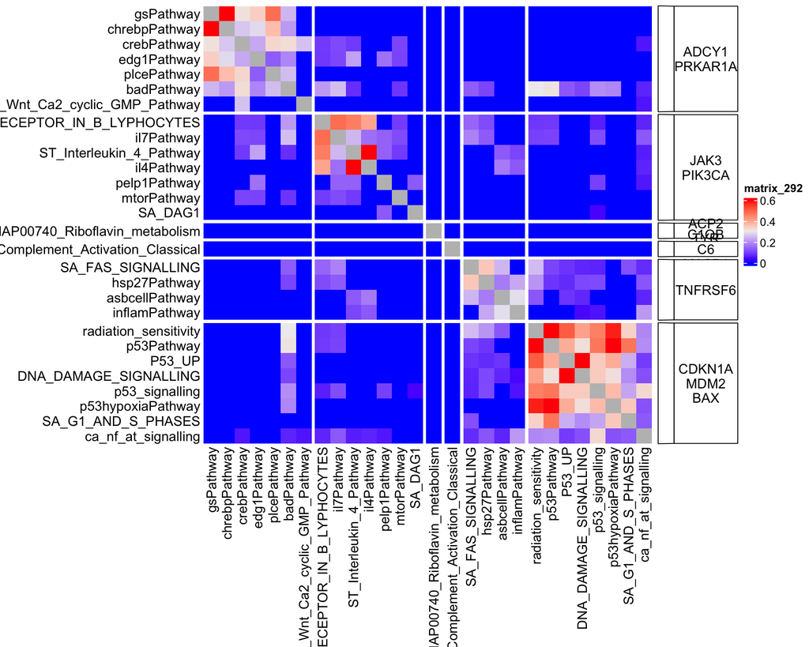

```r
ht + rowAnnotation(gene = anno_link(cl, panel_fun = function(index) {
    tb = table(unlist(gs2[index]))
    tb = sort(tb, decreasing = TRUE)
    pushViewport(viewport())
    grid.rect()
    grid.text(paste(names(tb)[tb/length(index) > 0.5], collapse = "\n"))
    popViewport()
}))
```

In the **GSEAtutorial** package, there is a `genesets_similarity_heatmap()` function.

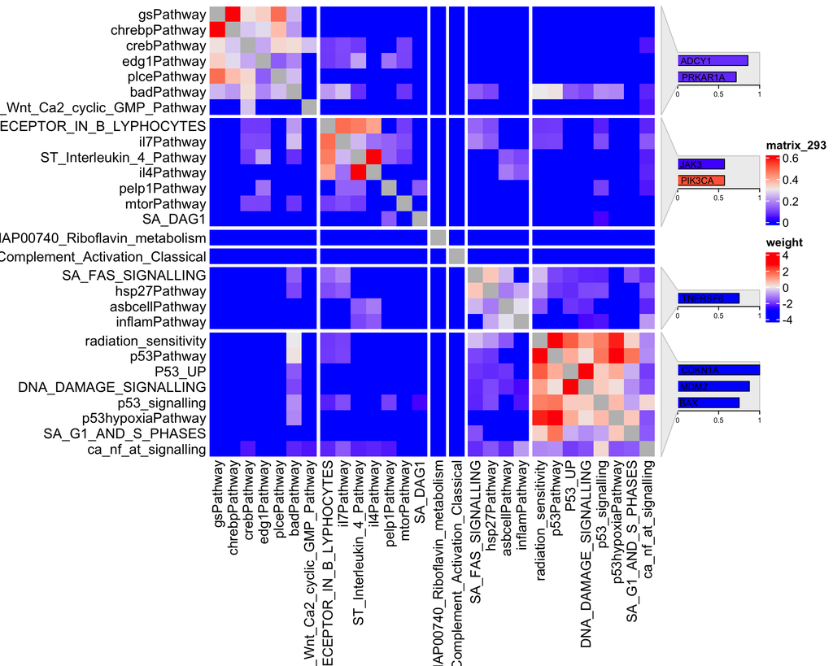

```r
genesets_similarity_heatmap(gs2, weight = w)
```

**Question**: in the previous example, the enrichment is done by ORA which is based on gene counts. The similarity is also based on gene counts. What if the enrichment is done by GSEA? How to adjust the calculation process?

We first apply the GSEA analysis.

```r
library(matrixStats)
m1 = expr[, condition == "WT"]  # only samples in group 1
m2 = expr[, condition == "MUT"]  # only samples in group 2
s = (rowMeans(m2) - rowMeans(m1))/(rowSds(m1) + rowSds(m2)) # gene-level difference scores
s = sort(s, decreasing = TRUE)
tb_gsea = fgsea_wrapper(s, gs)
head(tb_gsea)
```

```
##                       gene_set      p_value    p_adjust log2_p_err         es
## 1                       P53_UP 6.268618e-06 0.001847940  0.6105269 -0.5986774
## 2                 hsp27Pathway 7.511952e-06 0.001847940  0.6105269 -0.7758925
## 3                   p53Pathway 1.345579e-05 0.002206750  0.5933255 -0.7438596
## 4 GPCRs_Class_A_Rhodopsin-like 1.846297e-05 0.002270945  0.5756103 -0.4299558
## 5                     HTERT_UP 3.665398e-05 0.003606752  0.5573322  0.3709129
## 6               UPREG_BY_HOXA9 4.891826e-05 0.004011297  0.5573322  0.5828988
##         nes n_gs leading_edge
## 1 -2.155574   40 CDKN1A, ....
## 2 -2.183087   15 TNFRSF6,....
## 3 -2.124640   16 CDKN1A, ....
## 4 -1.849367  111 NTSR2, A....
## 5  1.867598  109 AHR, DR1....
## 6  2.202944   29 YES1, TD....
```

The similarity in this category is based on gene counts. Although the enrichment procedure is not gene count-based. In the results, GSEA reports “leading edge genes” which are the genes that contribute most to the enrichment of the gene set. These leading-edge genes can be used for calculating the similarities.

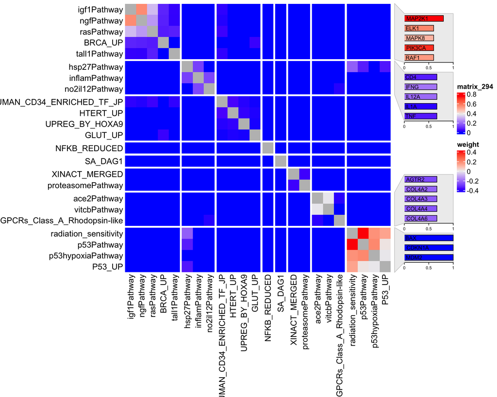

```r
l = tb_gsea$p_adjust < 0.1
gs3 = tb_gsea[l, "leading_edge"]
names(gs3) = tb_gsea$gene_set[l]
genesets_similarity_heatmap(gs3, weight = s, resolution = 2)
```

**Thoughts**: GSVA or the single-sample GSEA converts the original gene-sample matrix to geneset-sample matrix. One the aim of such transformation is to find “co-expressed gene sets”. As such “co-expression” is actually due to common genes in the gene sets, we can also do such driving-gene analysis and associated to a group of “co-expressed” genes.

## Semantic similarity

**simplifyEnrichment** is suggested to work on GO enrichment results.

Let’s generate 500 random GO IDs:

```r
library(simplifyEnrichment)
set.seed(888)
go_id = random_GO(500)
sm = GO_similarity(go_id)
```

The default semantic similarity method is “Sim_XGraSM_2013”, which is an adjusted Lin-1998 method, where $IC(MICA)$ replaced with $\mathrm{avg} IC(CA)$, i.e. average non-zero IC of all common ancestors.

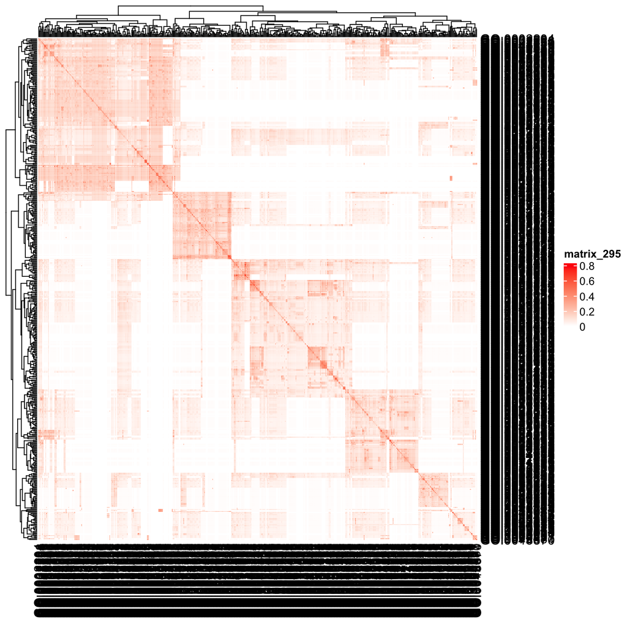

```r
Heatmap(sm, col = c("white", "red"))
```

The heatmap shows very clear block patterns on the diagonal. We next try several clustering methods to see whether they can capture such patterns.

We implement a helper function `test_clustering()` which accepts a cluster label vector and draws the heatmap.

```r
test_clustering = function(cl) {
    col_fun = colorRamp2(c(0, quantile(sm, 0.99)), c("white", "red"))
    Heatmap(sm, col = col_fun, border = "black", show_row_names = FALSE, show_column_names = FALSE,
        show_row_dend = FALSE, show_column_dend = FALSE, row_title = NULL, column_title = NULL,
        row_split = cl, column_split = cl)
}
```

We try hierarchical cluster, k-means, graph-based method and binary cut.

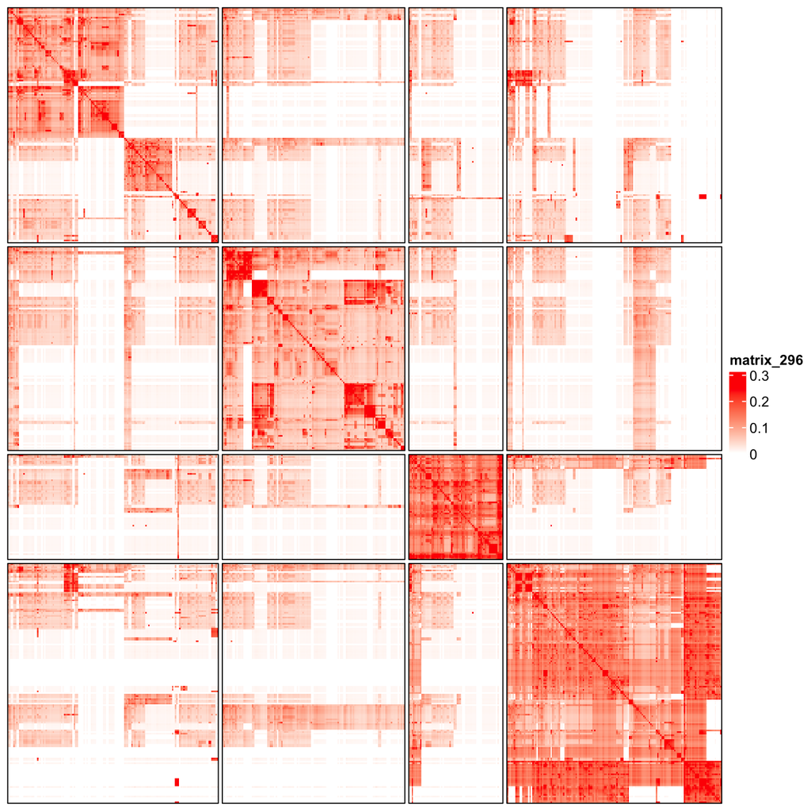

```r
cl = cutree(hclust(dist(sm)), k = 4)
test_clustering(cl)
```

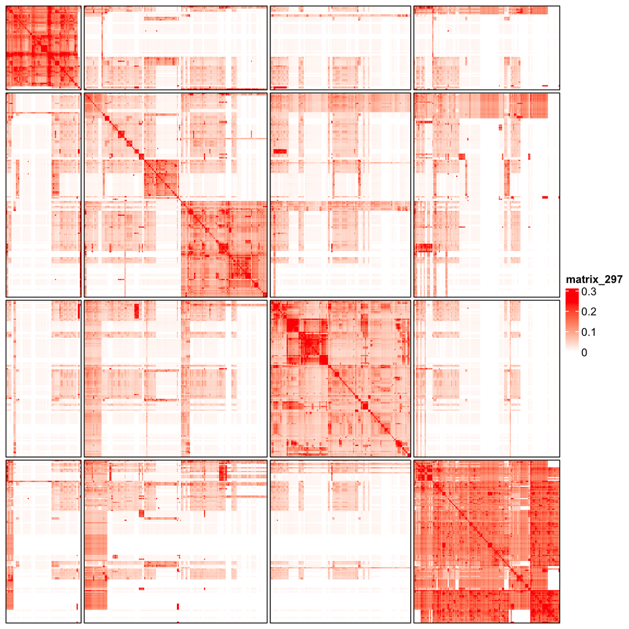

```r
cl = kmeans(dist(sm), centers = 4)$cluster
test_clustering(cl)
```

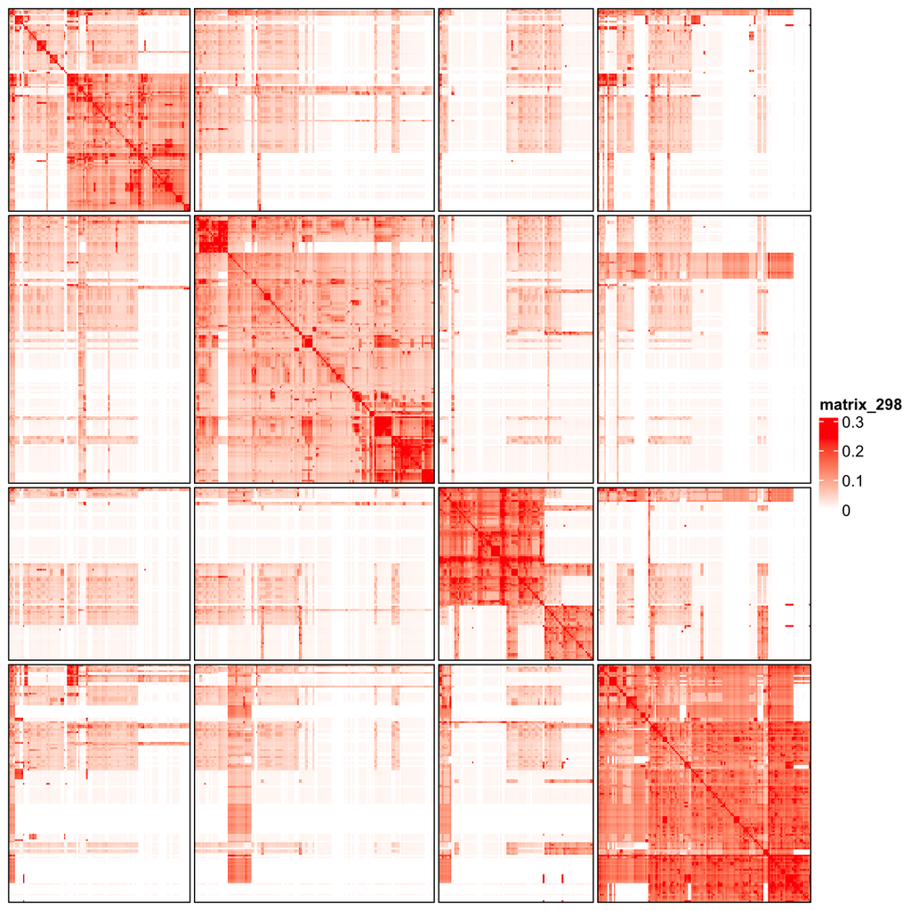

```r
g = graph_from_adjacency_matrix(sm, weighted = TRUE, mode = "upper", diag = FALSE)
cl = membership(cluster_louvain(g))
test_clustering(cl)
```

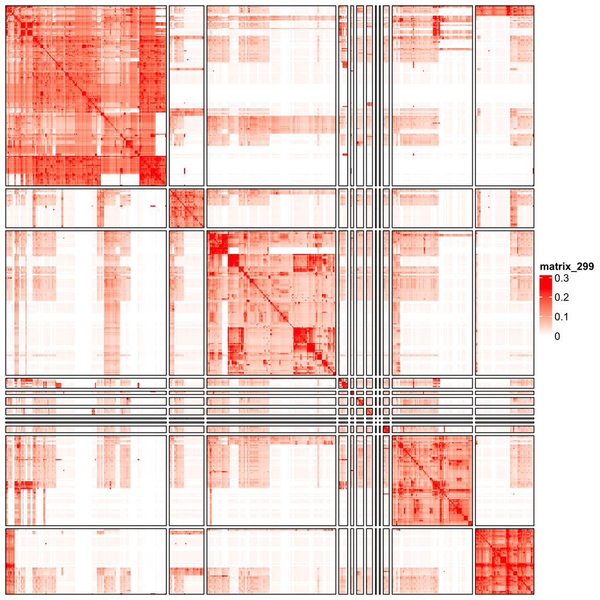

```r
cl = binary_cut(sm)
test_clustering(cl)
```

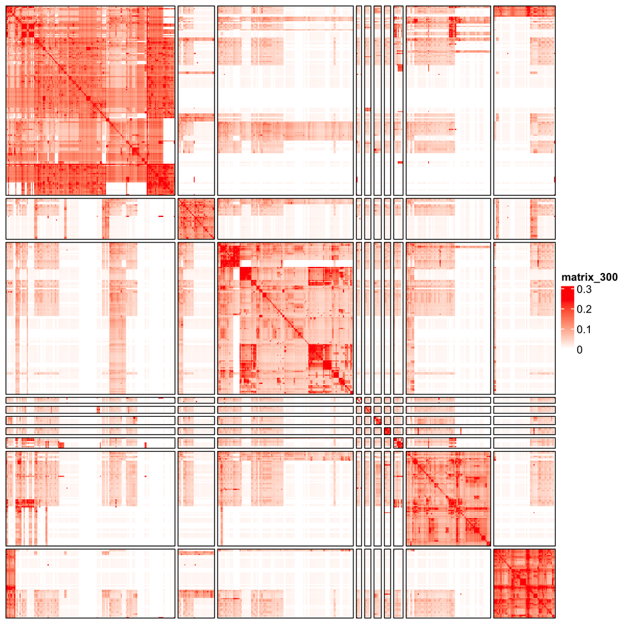

```r
cl = as.character(cl)
tb = table(cl)
cl[cl %in% names(tb[tb < 5])] = "others"
test_clustering(cl)
```

As GO terms in a cluster show high semantic similarities, where they should be concentrated in a certain GO branch. The general biological functions for a GO cluster is summarized by keywords and visualized by word cloud.

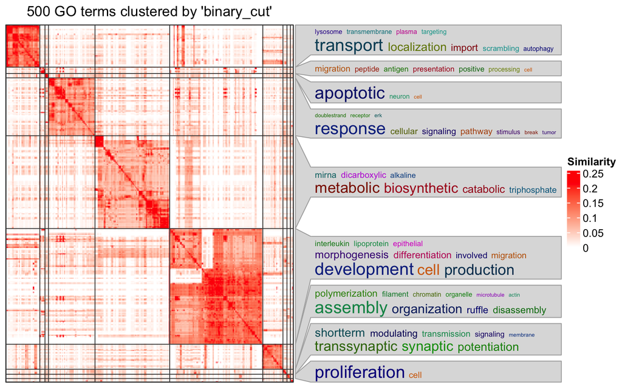

```r
simplifyGO(go_id)
```

## Multiple enrichment results

We follow the standard workflow for unsupervised cluster analysis. We use the Golub ALL dataset and the **cola** package for analysis.

```r
library(cola)

library(golubEsets)
data(Golub_Merge)
m = exprs(Golub_Merge)

anno = pData(Golub_Merge)

m[m <= 1] = NA
m = log10(m)

m = adjust_matrix(m)

library(preprocessCore)
cn = colnames(m)
rn = rownames(m)
m = normalize.quantiles(m)
colnames(m) = cn
rownames(m) = rn

res = consensus_partition(m, top_value_method = "ATC", partition_method = "skmeans", verbose = FALSE)
```

We know the best number of subgroups is three. We look for signatures in the three-subgroup classification.

```r
df = get_signatures(res, k = 3)
```

```
## * 71/72 samples (in 3 classes) remain after filtering by silhouette (>= 0.5).
## * cache hash: bc6884118a3de686a9e28200827a1400 (seed 888).
## * calculating row difference between subgroups by Ftest.
## * split rows into 4 groups by k-means clustering.
## * 2080 signatures (50.5%) under fdr < 0.05, group_diff > 0.
##   - randomly sample 2000 signatures.
## * making heatmaps for signatures.
```

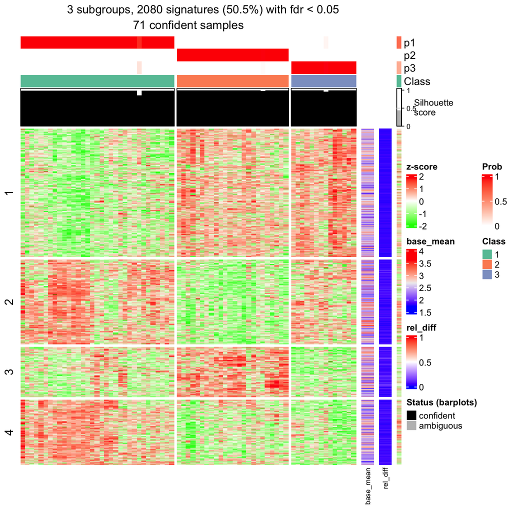

Now we have four groups of signatures genes. The next analysis is to compare enriched GO functions in the four lists of signature genes. The corresponding biological question is do these different signature genes have similar function or they exhibit specific functions?

We first obtain the four list of signature genes.

```r
gl = split(df$which_row, df$km)
gl = lapply(gl, function(ind) rownames(res)[ind])
```

The ALL data is almost 25 years ago. The gene ID is Affymetric microarray probe ID, Luckily, the corresponding annotation package is also available on Bioconductor which is built upon the standard **AnnotationDbi** package.

```r
library(hu6800.db)
gl = lapply(gl, function(x) {
    x2 = mapIds(hu6800.db, keys = x, keytype = "PROBEID", column = "ENTREZID")
    unique(x2[!is.na(x2)])
})
```

We aply ORA GO analysis.

```r
tbl = lapply(gl, ora_go)
```

`tbl` is a list of four enrichment result tables. `simplifyGOFromMultipleLists()` can be used to visualize GO enrichment from multiple results. The columns for GO IDs and p-values are automatically detected.

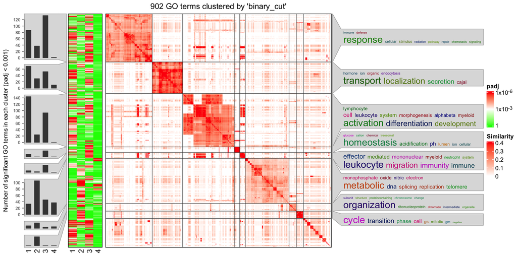

```r
simplifyGOFromMultipleLists(tbl, padj_cutoff = 0.001)
```

## Word cloud

In some cases, the similarity heatmap is not necessary to put into the final report.

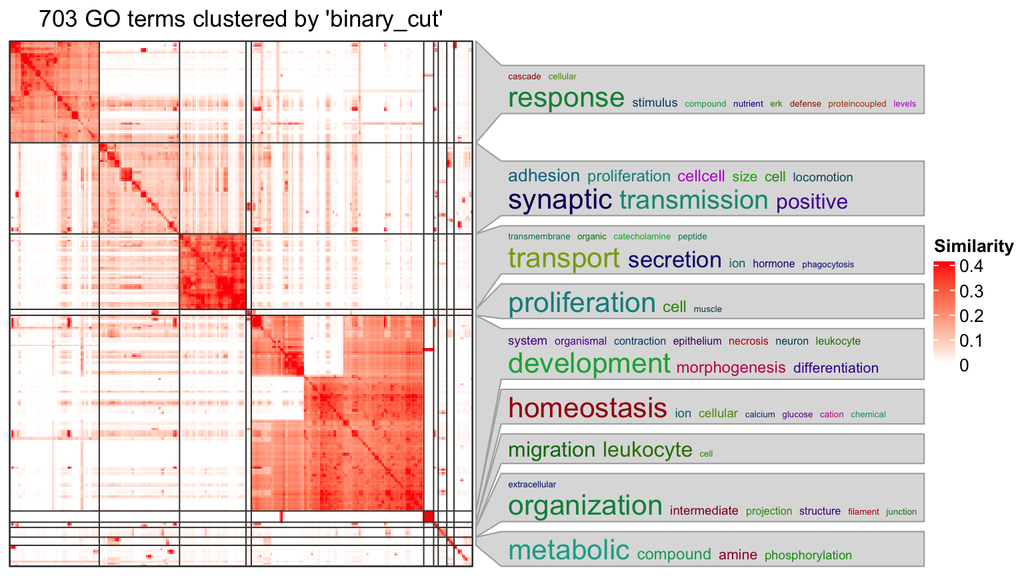

```r
df = tbl[[1]]
go_id = df$gene_set[df$p_adjust < 0.01]
simplifyGO(go_id)
```

`summarizeGO()` makes an even simpler plot with word cloud and simple statistical graphics.

When there is only one enrichment results, there are two inputs for `summarizeGO()`:

- A vector of GO IDs
- A numeric vector of corresponding statistics which are mapped to barplots.

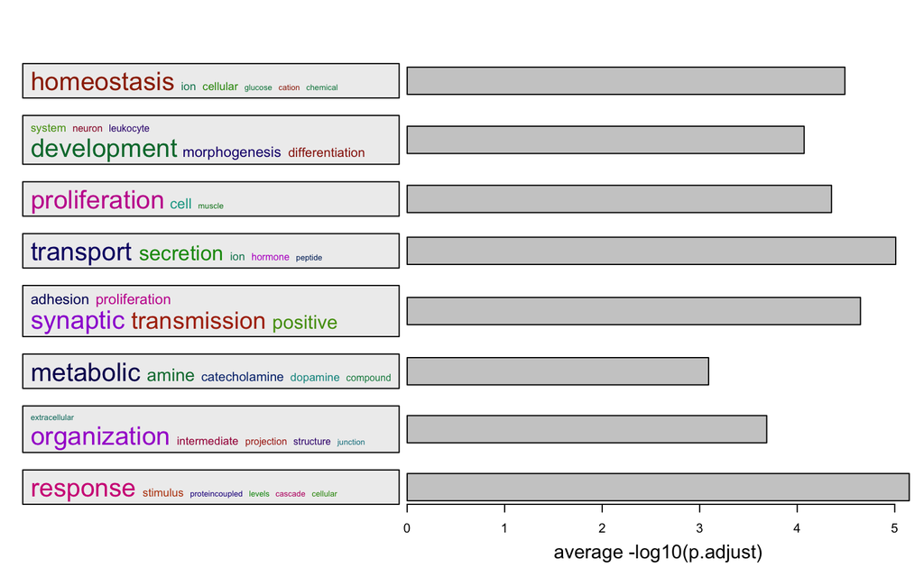

```r
l = df$p_adjust < 0.01
summarizeGO(df$gene_set[l], -log10(df$p_adjust)[l], axis_label = "average -log10(p.adjust)")
```

Or visualize average log2 fold enrichment:

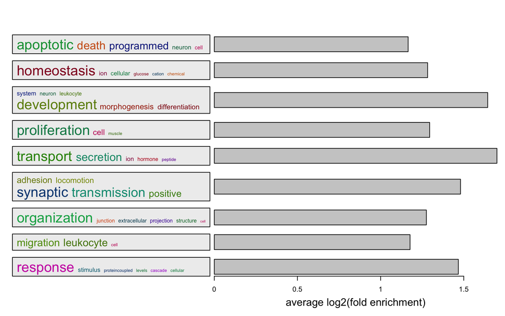

```r
l = df$p_adjust < 0.01
summarizeGO(df$gene_set[l], df$log2fe[l], axis_label = "average log2(fold enrichment)")
```

`summarizeGO()` also supports multiple enrichment results. In this case, `value` should be is a list of numeric named vectors which contains significant GO terms in each enrichment table.

```r
value = lapply(tbl, function(df) {
    v = -log10(df$p_adjust)
    names(v) = df$gene_set
    v[df$p_adjust < 0.001]
})
value
```

```
## $`1`
## GO:1901700 GO:0070887 GO:0007267 GO:1901701 GO:0033993 GO:0014070 GO:0009719
##  26.237880  26.237880  19.117876  18.342527  15.982658  15.802795  15.668856
## GO:0051049 GO:0042127 GO:1901698 GO:0009628 GO:0008283 GO:0003013 GO:0003008
##  15.349223  15.288059  15.280022  15.177717  14.710045  14.631086  14.222436
## GO:0051240 GO:0008015 GO:0051046 GO:0009888 GO:1901699 GO:0051050 GO:0032879
##  13.623170  13.177777  12.941955  12.930950  12.870733  12.524319  12.437768
## GO:0009725 GO:0007155 GO:0046903 GO:0009611 GO:0042592 GO:0048646 GO:0048584
##  12.391683  12.334096  12.185789  12.183578  11.843809  11.327376  11.134010
## GO:0007610 GO:0007167 GO:0032940 GO:0023061 GO:0008219 GO:0010647 GO:0009410
##  10.542744  10.017866   9.824256   9.824256   9.711838   9.656712   9.656712
## GO:0023056 GO:1903530 GO:0006915 GO:0071495 GO:0012501 GO:0140352 GO:0141124
##   9.656712   9.649104   9.537421   9.536453   9.519318   9.479174   9.303165
## GO:0042886 GO:0099536 GO:0044093 GO:0007268 GO:0098916 GO:0002791 GO:0090087
##   9.187950   9.108092   9.091732   9.091732   9.091732   9.087611   9.087611
## GO:0046879 GO:0099537 GO:0065009 GO:0002682 GO:0060429 GO:0060322 GO:0035295
##   9.012941   8.985766   8.985766   8.894611   8.825612   8.790232   8.750614
## GO:0030155 GO:0002790 GO:0043067 GO:0009914 GO:0090276 GO:0046883 GO:0072359
##   8.700197   8.653173   8.634919   8.634845   8.631165   8.494039   8.380531
## GO:0030072 GO:0045785 GO:0042391 GO:0044057 GO:0045595 GO:0015833 GO:0042981
##   8.367409   8.325714   8.325714   8.325714   8.144660   8.131611   8.128996
## GO:0035239 GO:0001775 GO:0006811 GO:0007417 GO:0003012 GO:0048732 GO:0040011
##   8.124350   8.116042   8.024183   7.981988   7.880974   7.836434   7.836434
## GO:0008285 GO:0043410 GO:0006936 GO:0030855 GO:0022008 GO:0048511 GO:0071407
##   7.740758   7.688693   7.688693   7.649087   7.636127   7.609210   7.591424
## GO:0009967 GO:0048666 GO:0016477 GO:0010817 GO:0043269 GO:0009887 GO:0008284
##   7.591424   7.548655   7.525259   7.525259   7.501491   7.501491   7.467166
## GO:0008217 GO:1901652 GO:0071396 GO:0006959 GO:0002684 GO:0019725 GO:0070482
##   7.446697   7.321351   7.304368   7.239157   7.226150   7.226150   7.216480
## GO:2000026 GO:0048514 GO:0022407 GO:0061564 GO:0007409 GO:0036293 GO:0001666
##   7.183680   7.183680   7.183680   7.173894   7.173737   7.076812   7.021125
## GO:0050878 GO:0031667 GO:0007169 GO:1902531 GO:1902533 GO:0001944 GO:0034097
##   7.019055   7.014781   7.008117   6.975236   6.973004   6.952449   6.920756
## GO:0040012 GO:0001568 GO:0048878 GO:0022603 GO:0007420 GO:0001525 GO:0030097
##   6.874066   6.859592   6.826336   6.820696   6.802012   6.759689   6.755810
## GO:0045944 GO:1903522 GO:0030182 GO:0043434 GO:0000165 GO:0050804 GO:0015837
##   6.654914   6.654454   6.654454   6.629380   6.618972   6.579857   6.574603
## GO:0051094 GO:0099177 GO:0098657 GO:0071692 GO:0042110 GO:0030001 GO:0043408
##   6.564673   6.563799   6.559768   6.546070   6.532801   6.529135   6.503087
## GO:0098609 GO:0048729 GO:0048699 GO:0045893 GO:0051047 GO:1902680 GO:0003018
```

[output cut: 296 more lines]

```
##  13.868466  13.683409  13.683409  12.937512  11.778725  11.778725   8.241828
## GO:0022904 GO:0042773 GO:0042775 GO:0022900 GO:0050684 GO:0045333 GO:0009060
##   8.078478   7.794270   7.794270   7.612713   7.593116   7.509593   7.131808
## GO:0048024 GO:0006119 GO:0015980 GO:0043933 GO:0006403 GO:0043484 GO:0065003
##   7.105427   7.016101   6.980564   6.510571   6.304517   6.096048   6.002122
## GO:0033554 GO:0006091 GO:0010498 GO:0009057 GO:0051603 GO:0071826 GO:0030163
##   5.849506   5.667988   5.667988   5.627213   4.833333   4.680597   4.598255
## GO:0043161 GO:0006511 GO:0006913 GO:0051169 GO:0019941 GO:0022618 GO:0043632
##   4.554753   4.545962   4.483098   4.483098   4.428983   4.376702   4.376702
## GO:0046907 GO:1903311 GO:0006457 GO:0006396 GO:0006123 GO:0006458 GO:0022613
##   4.352925   4.242742   4.236618   4.236618   4.125795   3.953331   3.725514
## GO:0050657 GO:0050658 GO:0006886 GO:0071705 GO:0033365 GO:0051236 GO:0051246
##   3.613870   3.613870   3.613870   3.599866   3.599866   3.544004   3.480332
## GO:0051084 GO:0000380 GO:0045934 GO:0006122
##   3.364506   3.345405   3.083965   3.017274
```

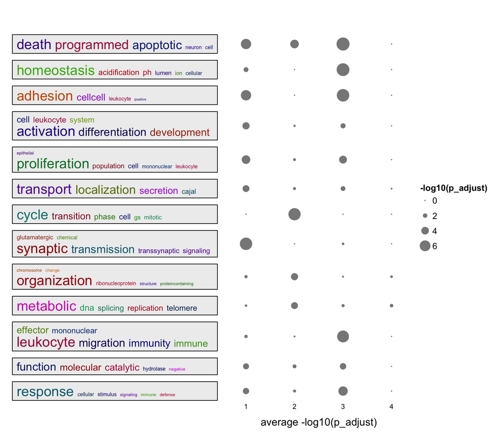

```r
summarizeGO(value = value, axis_label = "average -log10(p_adjust)",
    legend_title = "-log10(p_adjust)")
```

Or use log2 fold enrichment:

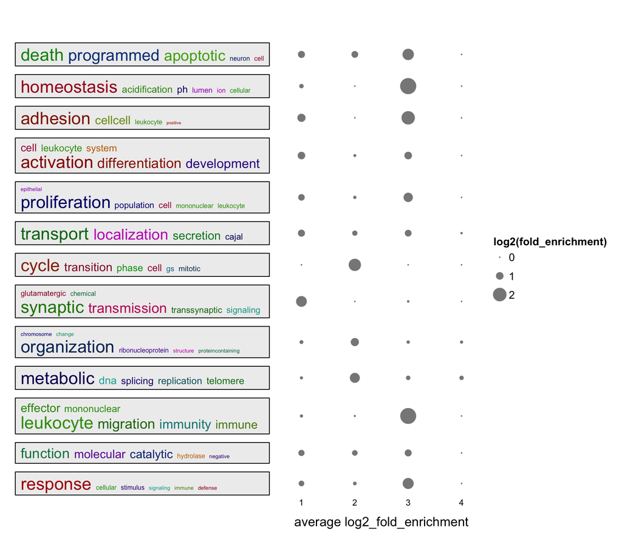

```r
value = lapply(tbl, function(df) {
    v = df$log2fe
    names(v) = df$gene_set
    v[df$p_adjust < 0.001]
})
summarizeGO(value = value, axis_label = "average log2_fold_enrichment",
    legend_title = "log2(fold_enrichment)")
```

## Practice

#### Practice 1

Recall in Topic 2-02: Implement ORA from stratch, we compared the ORA results when setting DE cutoffs to 0.05, 0.01 and 0.001. Now perform a simplify enrichment analysis on the three ORA tables and compare them.

```r
de = readRDS(system.file("extdata", "de.rds", package = "GSEAtraining"))
de = de[, c("symbol", "p_value")]
de = de[!is.na(de$p_value), ]

de_genes_1 = de$symbol[de$p_value < 0.05]
de_genes_2 = de$symbol[de$p_value < 0.01]
de_genes_3 = de$symbol[de$p_value < 0.001]

library(GSEAtraining)
library(org.Hs.eg.db)
gs = get_GO_gene_sets_from_orgdb(org.Hs.eg.db, "BP", gene_id_type = "SYMBOL")

tb1 = ora(de_genes_1, gs)
tb2 = ora(de_genes_2, gs)
tb3 = ora(de_genes_3, gs)
```

#### Solution

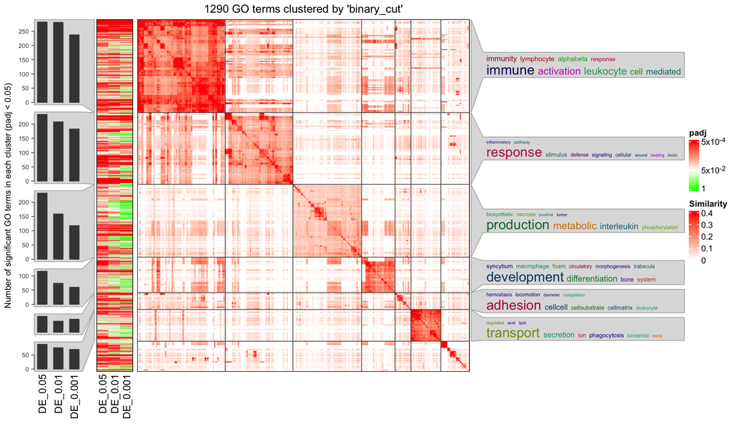

```r
lt = list(
    "DE_0.05" = tb1,
    "DE_0.01" = tb2,
    "DE_0.001" = tb3
)

simplifyGOFromMultipleLists(lt, padj_cutoff = 0.05)
```